# Zadanie 3

Wiktor Borowik, Michal Rasinski

26 11 2020

Poniżej znajduje sie podsumowanie zmiennych w zbiorze danych:

```r
str(churnData)
```

```
## 'data.frame':    5000 obs. of  20 variables:
##  $ state                        : Factor w/ 51 levels "AK","AL","AR",..: 17 36 32 36 37 2 20 25 19 50 ...
##  $ account_length               : int  128 107 137 84 75 118 121 147 117 141 ...
##  $ area_code                    : Factor w/ 3 levels "area_code_408",..: 2 2 2 1 2 3 3 2 1 2 ...
##  $ international_plan           : Factor w/ 2 levels "no","yes": 1 1 1 2 2 2 1 2 1 2 ...
##  $ voice_mail_plan              : Factor w/ 2 levels "no","yes": 2 2 1 1 1 1 2 1 1 2 ...
##  $ number_vmail_messages        : int  25 26 0 0 0 0 24 0 0 37 ...
##  $ total_day_minutes            : num  265 162 243 299 167 ...
##  $ total_day_calls              : int  110 123 114 71 113 98 88 79 97 84 ...
##  $ total_day_charge             : num  45.1 27.5 41.4 50.9 28.3 ...
##  $ total_eve_minutes            : num  197.4 195.5 121.2 61.9 148.3 ...
##  $ total_eve_calls              : int  99 103 110 88 122 101 108 94 80 111 ...
##  $ total_eve_charge             : num  16.78 16.62 10.3 5.26 12.61 ...
##  $ total_night_minutes          : num  245 254 163 197 187 ...
##  $ total_night_calls            : int  91 103 104 89 121 118 118 96 90 97 ...
##  $ total_night_charge           : num  11.01 11.45 7.32 8.86 8.41 ...
##  $ total_intl_minutes           : num  10 13.7 12.2 6.6 10.1 6.3 7.5 7.1 8.7 11.2 ...
##  $ total_intl_calls             : int  3 3 5 7 3 6 7 6 4 5 ...
##  $ total_intl_charge            : num  2.7 3.7 3.29 1.78 2.73 1.7 2.03 1.92 2.35 3.02 ...
##  $ number_customer_service_calls: int  1 1 0 2 3 0 3 0 1 0 ...
##  $ churn                        : Factor w/ 2 levels "yes","no": 2 2 2 2 2 2 2 2 2 2 ...
```

Usunicie trzech zmiennych, które nie nadaja sie do klasyfikacji:

```r
churnTrain <- churnData[,!names(churnData) %in% c("state", "area_code", "account_length")]
```

Poniżej zmieniamy klasy dwóch zmiennych:

```r
levels(churnTrain$international_plan) <- list("0" ="no", "1"="yes")
levels(churnTrain$voice_mail_plan) <- list("0" ="no", "1"="yes")
str(churnTrain)
```

```
## 'data.frame':    5000 obs. of  17 variables:
##  $ international_plan           : Factor w/ 2 levels "0","1": 1 1 1 2 2 2 1 2 1 2 ...
##  $ voice_mail_plan              : Factor w/ 2 levels "0","1": 2 2 1 1 1 1 2 1 1 2 ...
##  $ number_vmail_messages        : int  25 26 0 0 0 0 24 0 0 37 ...
##  $ total_day_minutes            : num  265 162 243 299 167 ...
##  $ total_day_calls              : int  110 123 114 71 113 98 88 79 97 84 ...
##  $ total_day_charge             : num  45.1 27.5 41.4 50.9 28.3 ...
##  $ total_eve_minutes            : num  197.4 195.5 121.2 61.9 148.3 ...
##  $ total_eve_calls              : int  99 103 110 88 122 101 108 94 80 111 ...
##  $ total_eve_charge             : num  16.78 16.62 10.3 5.26 12.61 ...
##  $ total_night_minutes          : num  245 254 163 197 187 ...
##  $ total_night_calls            : int  91 103 104 89 121 118 118 96 90 97 ...
##  $ total_night_charge           : num  11.01 11.45 7.32 8.86 8.41 ...
##  $ total_intl_minutes           : num  10 13.7 12.2 6.6 10.1 6.3 7.5 7.1 8.7 11.2 ...
##  $ total_intl_calls             : int  3 3 5 7 3 6 7 6 4 5 ...
##  $ total_intl_charge            : num  2.7 3.7 3.29 1.78 2.73 1.7 2.03 1.92 2.35 3.02 ...
##  $ number_customer_service_calls: int  1 1 0 2 3 0 3 0 1 0 ...
##  $ churn                        : Factor w/ 2 levels "yes","no": 2 2 2 2 2 2 2 2 2 2 ...
```

Dzielenie zestawu danych na dwa zbiory: zbior treningowy i zbior testowy (odpowiednio 75% i 25%):

```r
set.seed(23)
data_division <-
    createDataPartition(
        y = churnTrain$churn,
        p = .75,
        list = FALSE)

trainset <- churnTrain[ data_division,]
testset <- churnTrain[-data_division,]
```

Sprawdzenie wymiarów podzielonych danych:

```r
pander::pander(dim(trainset))
```

*3751* and *17*

```r
pander::pander(dim(testset))
```

*1249* and *17*

Funkcja fitConrtol:

```r
fitControl <- trainControl(method = "repeatedcv",
                           number = 10,
                           repeats = 10,
                           classProbs = TRUE,
                           summaryFunction = twoClassSummary)
```

Klasyfikator 1. - KNN (K- nearest neighbours):

```r
model_knn <- train(churn ~ ., data = trainset,
                 method = "knn",
                 trControl = fitControl,
                 metric = "ROC")
model_knn
```

```
## k-Nearest Neighbors
##
## 3751 samples
##   16 predictor
##    2 classes: 'yes', 'no'
##
## No pre-processing
## Resampling: Cross-Validated (10 fold, repeated 10 times)
## Summary of sample sizes: 3376, 3375, 3376, 3376, 3376, 3376, ...
## Resampling results across tuning parameters:
##
##   k  ROC        Sens       Spec
##   5  0.7080391  0.3474668  0.9788820
##   7  0.7132176  0.3376834  0.9853106
##   9  0.7187259  0.3286548  0.9886646
##
## ROC was used to select the optimal model using the largest value.
## The final value used for the model was k = 9.
```

Predyckja modelu knn:

```r
rfClasses <- predict(model_knn, newdata = testset)
confusionMatrix(data = rfClasses, testset$churn)
```

```
## Confusion Matrix and Statistics
##
##           Reference
## Prediction  yes   no
##        yes   60   15
##        no   116 1058
##
##                Accuracy : 0.8951
##                  95% CI : (0.8768, 0.9116)
##     No Information Rate : 0.8591
##     P-Value [Acc > NIR] : 8.742e-05
##
##                   Kappa : 0.4301
##
##  Mcnemar's Test P-Value : < 2.2e-16
##
##             Sensitivity : 0.34091
##             Specificity : 0.98602
##          Pos Pred Value : 0.80000
##          Neg Pred Value : 0.90119
##              Prevalence : 0.14091
##          Detection Rate : 0.04804
##    Detection Prevalence : 0.06005
##       Balanced Accuracy : 0.66346
##
##        'Positive' Class : yes
##
```

Klasyfikator 2. - SVM (Supporting Vector Machine):

```r
set.seed(825)
svmFit <- train(churn ~ ., data = trainset,
                 method = "svmRadial",
                 trControl = fitControl,
                 preProc = c("center", "scale"),
                 tuneLength = 2,
                 metric = "ROC")
svmFit
```

```
## Support Vector Machines with Radial Basis Function Kernel
##
## 3751 samples
##   16 predictor
##    2 classes: 'yes', 'no'
##
## Pre-processing: centered (16), scaled (16)
## Resampling: Cross-Validated (10 fold, repeated 10 times)
## Summary of sample sizes: 3376, 3376, 3376, 3376, 3376, 3376, ...
## Resampling results across tuning parameters:
##
##   C     ROC        Sens       Spec
##   0.25  0.9148574  0.6653843  0.9674534
##   0.50  0.9177425  0.6529595  0.9754037
##
## Tuning parameter 'sigma' was held constant at a value of 0.04382532
## ROC was used to select the optimal model using the largest value.
## The final values used for the model were sigma = 0.04382532 and C = 0.5.
```

Predyckja modelu SVM:

```r
rfClasses <- predict(svmFit, newdata = testset)
confusionMatrix(data = rfClasses, testset$churn)
```

```
## Confusion Matrix and Statistics
##
##           Reference
## Prediction  yes   no
##        yes  113   30
##        no    63 1043
##
##                Accuracy : 0.9255
##                  95% CI : (0.9096, 0.9395)
##     No Information Rate : 0.8591
##     P-Value [Acc > NIR] : 1.901e-13
##
##                   Kappa : 0.6663
##
##  Mcnemar's Test P-Value : 0.0009058
##
##             Sensitivity : 0.64205
##             Specificity : 0.97204
##          Pos Pred Value : 0.79021
##          Neg Pred Value : 0.94304
##              Prevalence : 0.14091
##          Detection Rate : 0.09047
##    Detection Prevalence : 0.11449
##       Balanced Accuracy : 0.80704
##
##        'Positive' Class : yes
##
```

Porównanie parametrów obu klasyfikatorów przedstawiono na poniższym wykresie porównawczym:

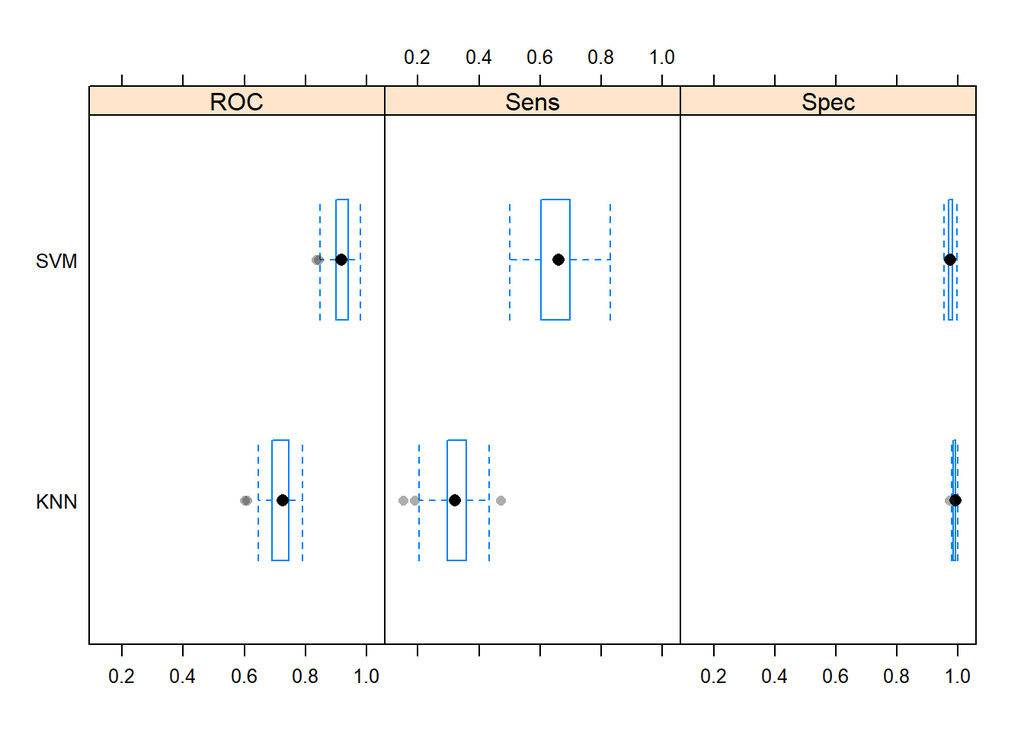

```r
trellis.par.set(theme1)
bwplot(resamps, layout = c(3, 1))
```

# Podsumowanie

Okazalo sie, że lepsze wyniki klasyfikacji uzyskalismy stosujac klasyfikator SVM, aniżeli klasyfikatorem KNN. Klasyfikator SVM idelanie nadaje sie do zbiorów danych z dwuwartosciowa klasa decyzyjna, poniewaz dzieli hiperplaszczyzne na dwie czescie - każda dla odpowiedniej klasy.

Wstepne przetworzenie zbioru danych na pewno poprawiloby osiagi obydwoch klasyfikatorow. Stworzone klasyfikatory dzialaly na bardzo duzej liczbie wymiarow, z czego wiekszosc bylaby prawdopodobnie zbedna. Usunelismy jedynie 3 zmienne ze zbioru danych, ktore w zaden sposob nie pomoglyby zaklasyfikowac danych. Aby usprawnic proces uczenia i finalne osiagi wybranych przez nas klasyfikatorow dokonalibysmy redukcji wymiarow.